# Risk Factor Analysis

## Outcome Variable

**Outcome Variable:** wasted

## Predictor Variables

**Intervention Variable:** perdiar6

**Adjustment Set:**

unadjusted

## Stratifying Variables

The analysis was stratified on these variable(s):

- agecat
- studyid
- country

## Data Summary

| agecat | studyid | country | perdiar6 | wasted | n_cell | n | outcome_variable |
| --- | --- | --- | --- | --- | --- | --- | --- |
| Birth | ki0047075b-MAL-ED | BANGLADESH | 0% | 0 | 55 | 215 | wasted |
| Birth | ki0047075b-MAL-ED | BANGLADESH | 0% | 1 | 10 | 215 | wasted |
| Birth | ki0047075b-MAL-ED | BANGLADESH | (0%, 5%] | 0 | 69 | 215 | wasted |
| Birth | ki0047075b-MAL-ED | BANGLADESH | (0%, 5%] | 1 | 17 | 215 | wasted |
| Birth | ki0047075b-MAL-ED | BANGLADESH | >5% | 0 | 55 | 215 | wasted |
| Birth | ki0047075b-MAL-ED | BANGLADESH | >5% | 1 | 9 | 215 | wasted |
| Birth | ki0047075b-MAL-ED | BRAZIL | 0% | 0 | 53 | 62 | wasted |
| Birth | ki0047075b-MAL-ED | BRAZIL | 0% | 1 | 1 | 62 | wasted |
| Birth | ki0047075b-MAL-ED | BRAZIL | (0%, 5%] | 0 | 5 | 62 | wasted |
| Birth | ki0047075b-MAL-ED | BRAZIL | (0%, 5%] | 1 | 1 | 62 | wasted |
| Birth | ki0047075b-MAL-ED | BRAZIL | >5% | 0 | 2 | 62 | wasted |
| Birth | ki0047075b-MAL-ED | BRAZIL | >5% | 1 | 0 | 62 | wasted |
| Birth | ki0047075b-MAL-ED | INDIA | 0% | 0 | 10 | 45 | wasted |
| Birth | ki0047075b-MAL-ED | INDIA | 0% | 1 | 1 | 45 | wasted |
| Birth | ki0047075b-MAL-ED | INDIA | (0%, 5%] | 0 | 20 | 45 | wasted |
| Birth | ki0047075b-MAL-ED | INDIA | (0%, 5%] | 1 | 3 | 45 | wasted |
| Birth | ki0047075b-MAL-ED | INDIA | >5% | 0 | 10 | 45 | wasted |
| Birth | ki0047075b-MAL-ED | INDIA | >5% | 1 | 1 | 45 | wasted |
| Birth | ki0047075b-MAL-ED | NEPAL | 0% | 0 | 8 | 26 | wasted |
| Birth | ki0047075b-MAL-ED | NEPAL | 0% | 1 | 0 | 26 | wasted |
| Birth | ki0047075b-MAL-ED | NEPAL | (0%, 5%] | 0 | 9 | 26 | wasted |
| Birth | ki0047075b-MAL-ED | NEPAL | (0%, 5%] | 1 | 1 | 26 | wasted |
| Birth | ki0047075b-MAL-ED | NEPAL | >5% | 0 | 7 | 26 | wasted |
| Birth | ki0047075b-MAL-ED | NEPAL | >5% | 1 | 1 | 26 | wasted |
| Birth | ki0047075b-MAL-ED | PERU | 0% | 0 | 67 | 228 | wasted |
| Birth | ki0047075b-MAL-ED | PERU | 0% | 1 | 0 | 228 | wasted |
| Birth | ki0047075b-MAL-ED | PERU | (0%, 5%] | 0 | 69 | 228 | wasted |
| Birth | ki0047075b-MAL-ED | PERU | (0%, 5%] | 1 | 0 | 228 | wasted |
| Birth | ki0047075b-MAL-ED | PERU | >5% | 0 | 87 | 228 | wasted |
| Birth | ki0047075b-MAL-ED | PERU | >5% | 1 | 5 | 228 | wasted |

[output cut: 204 more lines]

The following strata were considered:

- agecat: 24 months, studyid: ki0047075b-MAL-ED, country: BANGLADESH
- agecat: 24 months, studyid: ki0047075b-MAL-ED, country: BRAZIL
- agecat: 24 months, studyid: ki0047075b-MAL-ED, country: INDIA
- agecat: 24 months, studyid: ki0047075b-MAL-ED, country: NEPAL
- agecat: 24 months, studyid: ki0047075b-MAL-ED, country: PERU
- agecat: 24 months, studyid: ki0047075b-MAL-ED, country: SOUTH AFRICA
- agecat: 24 months, studyid: ki0047075b-MAL-ED, country: TANZANIA, UNITED REPUBLIC OF
- agecat: 24 months, studyid: ki1000109-EE, country: PAKISTAN
- agecat: 24 months, studyid: ki1017093-NIH-Birth, country: BANGLADESH
- agecat: 24 months, studyid: ki1017093b-PROVIDE, country: BANGLADESH
- agecat: 24 months, studyid: ki1017093c-NIH-Crypto, country: BANGLADESH
- agecat: 24 months, studyid: ki1114097-CMIN, country: BANGLADESH
- agecat: 24 months, studyid: ki1114097-CONTENT, country: PERU
- agecat: 6 months, studyid: ki0047075b-MAL-ED, country: BANGLADESH
- agecat: 6 months, studyid: ki0047075b-MAL-ED, country: BRAZIL
- agecat: 6 months, studyid: ki0047075b-MAL-ED, country: INDIA
- agecat: 6 months, studyid: ki0047075b-MAL-ED, country: NEPAL
- agecat: 6 months, studyid: ki0047075b-MAL-ED, country: PERU
- agecat: 6 months, studyid: ki0047075b-MAL-ED, country: SOUTH AFRICA
- agecat: 6 months, studyid: ki0047075b-MAL-ED, country: TANZANIA, UNITED REPUBLIC OF
- agecat: 6 months, studyid: ki1000109-EE, country: PAKISTAN
- agecat: 6 months, studyid: ki1017093-NIH-Birth, country: BANGLADESH
- agecat: 6 months, studyid: ki1017093b-PROVIDE, country: BANGLADESH
- agecat: 6 months, studyid: ki1017093c-NIH-Crypto, country: BANGLADESH
- agecat: 6 months, studyid: ki1114097-CMIN, country: BANGLADESH
- agecat: 6 months, studyid: ki1114097-CONTENT, country: PERU
- agecat: Birth, studyid: ki0047075b-MAL-ED, country: BANGLADESH
- agecat: Birth, studyid: ki0047075b-MAL-ED, country: BRAZIL
- agecat: Birth, studyid: ki0047075b-MAL-ED, country: INDIA
- agecat: Birth, studyid: ki0047075b-MAL-ED, country: NEPAL
- agecat: Birth, studyid: ki0047075b-MAL-ED, country: PERU
- agecat: Birth, studyid: ki0047075b-MAL-ED, country: SOUTH AFRICA
- agecat: Birth, studyid: ki0047075b-MAL-ED, country: TANZANIA, UNITED REPUBLIC OF
- agecat: Birth, studyid: ki1000109-EE, country: PAKISTAN
- agecat: Birth, studyid: ki1017093-NIH-Birth, country: BANGLADESH
- agecat: Birth, studyid: ki1017093b-PROVIDE, country: BANGLADESH
- agecat: Birth, studyid: ki1017093c-NIH-Crypto, country: BANGLADESH
- agecat: Birth, studyid: ki1114097-CMIN, country: BANGLADESH
- agecat: Birth, studyid: ki1114097-CONTENT, country: PERU

### Dropped Strata

Some strata were dropped due to rare outcomes:

- agecat: Birth, studyid: ki0047075b-MAL-ED, country: BRAZIL
- agecat: Birth, studyid: ki0047075b-MAL-ED, country: INDIA
- agecat: Birth, studyid: ki0047075b-MAL-ED, country: NEPAL
- agecat: Birth, studyid: ki0047075b-MAL-ED, country: PERU
- agecat: Birth, studyid: ki0047075b-MAL-ED, country: SOUTH AFRICA
- agecat: Birth, studyid: ki0047075b-MAL-ED, country: TANZANIA, UNITED REPUBLIC OF
- agecat: Birth, studyid: ki1000109-EE, country: PAKISTAN
- agecat: Birth, studyid: ki1114097-CMIN, country: BANGLADESH
- agecat: Birth, studyid: ki1114097-CONTENT, country: PERU
- agecat: 6 months, studyid: ki0047075b-MAL-ED, country: BANGLADESH
- agecat: 6 months, studyid: ki0047075b-MAL-ED, country: BRAZIL
- agecat: 6 months, studyid: ki0047075b-MAL-ED, country: INDIA
- agecat: 6 months, studyid: ki0047075b-MAL-ED, country: NEPAL
- agecat: 6 months, studyid: ki0047075b-MAL-ED, country: PERU
- agecat: 6 months, studyid: ki0047075b-MAL-ED, country: SOUTH AFRICA
- agecat: 6 months, studyid: ki0047075b-MAL-ED, country: TANZANIA, UNITED REPUBLIC OF
- agecat: 6 months, studyid: ki1000109-EE, country: PAKISTAN
- agecat: 6 months, studyid: ki1017093c-NIH-Crypto, country: BANGLADESH
- agecat: 6 months, studyid: ki1114097-CMIN, country: BANGLADESH
- agecat: 6 months, studyid: ki1114097-CONTENT, country: PERU
- agecat: 24 months, studyid: ki0047075b-MAL-ED, country: BRAZIL
- agecat: 24 months, studyid: ki0047075b-MAL-ED, country: NEPAL
- agecat: 24 months, studyid: ki0047075b-MAL-ED, country: PERU
- agecat: 24 months, studyid: ki0047075b-MAL-ED, country: SOUTH AFRICA
- agecat: 24 months, studyid: ki0047075b-MAL-ED, country: TANZANIA, UNITED REPUBLIC OF
- agecat: 24 months, studyid: ki1000109-EE, country: PAKISTAN
- agecat: 24 months, studyid: ki1114097-CMIN, country: BANGLADESH
- agecat: 24 months, studyid: ki1114097-CONTENT, country: PERU

## Methods Detail

We’re interested in the causal parameters $E[Y_a]$ for all values of $a \in \mathcal{A}$. These parameters represent the mean outcome if, possibly contrary to fact, we intervened to set all units to have $A=a$. Under the randomization and positivity assumptions, these are identified by the statistical parameters $\psi_a=E_W[E_{Y|A,W}(Y|A=a,W)]$. In addition, we’re interested in the mean of $Y$, $E[Y]$ under no intervention (the observed mean). We will estimate these parameters by using SuperLearner to fit the relevant likelihood factors – $E_{Y|A,W}(Y|A=a,W)$ and $p(A=a|W)$, and then updating our likelihood fit using a joint TMLE.

For unadjusted analyses ($W=\{\}$), initial likelihoods were estimated using Lrnr_glm to estimate the simple $E(Y|A)$ and Lrnr_mean to estimate $p(A)$. For adjusted analyses, a small library containing Lrnr_glmnet, Lrnr_xgboost, and Lrnr_mean was used.

Having estimated these parameters, we will then use the delta method to estimate relative risks and attributable risks relative to a prespecified baseline level of $A$.

# Results Detail

## Results Plots

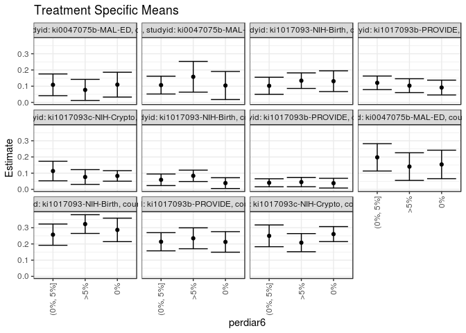

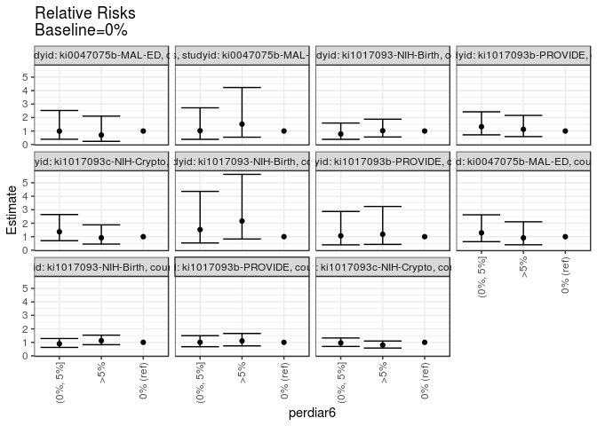

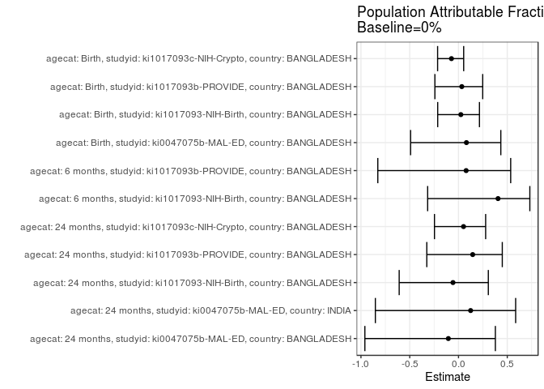

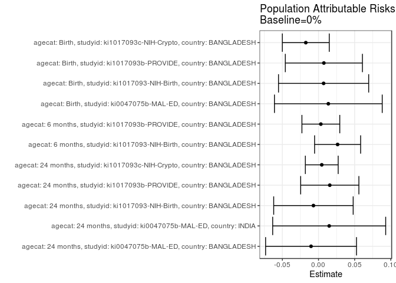

## Results Table

### Parameter: TSM

| agecat | studyid | country | intervention_level | baseline_level | estimate | ci_lower | ci_upper |
| --- | --- | --- | --- | --- | --- | --- | --- |
| Birth | ki0047075b-MAL-ED | BANGLADESH | 0% | NA | 0.1538462 | 0.0659294 | 0.2417629 |
| Birth | ki0047075b-MAL-ED | BANGLADESH | (0%, 5%] | NA | 0.1976744 | 0.1133095 | 0.2820393 |
| Birth | ki0047075b-MAL-ED | BANGLADESH | >5% | NA | 0.1406250 | 0.0552574 | 0.2259926 |
| Birth | ki1017093-NIH-Birth | BANGLADESH | 0% | NA | 0.2866667 | 0.2142369 | 0.3590965 |
| Birth | ki1017093-NIH-Birth | BANGLADESH | (0%, 5%] | NA | 0.2573099 | 0.1917314 | 0.3228885 |
| Birth | ki1017093-NIH-Birth | BANGLADESH | >5% | NA | 0.3227092 | 0.2648217 | 0.3805966 |
| Birth | ki1017093b-PROVIDE | BANGLADESH | 0% | NA | 0.2125000 | 0.1490544 | 0.2759456 |
| Birth | ki1017093b-PROVIDE | BANGLADESH | (0%, 5%] | NA | 0.2135922 | 0.1575727 | 0.2696118 |
| Birth | ki1017093b-PROVIDE | BANGLADESH | >5% | NA | 0.2349398 | 0.1703849 | 0.2994946 |
| Birth | ki1017093c-NIH-Crypto | BANGLADESH | 0% | NA | 0.2608696 | 0.2145016 | 0.3072375 |
| Birth | ki1017093c-NIH-Crypto | BANGLADESH | (0%, 5%] | NA | 0.2500000 | 0.1828577 | 0.3171423 |
| Birth | ki1017093c-NIH-Crypto | BANGLADESH | >5% | NA | 0.2079208 | 0.1519176 | 0.2639240 |
| 6 months | ki1017093-NIH-Birth | BANGLADESH | 0% | NA | 0.0387597 | 0.0054198 | 0.0720996 |
| 6 months | ki1017093-NIH-Birth | BANGLADESH | (0%, 5%] | NA | 0.0591716 | 0.0235657 | 0.0947774 |
| 6 months | ki1017093-NIH-Birth | BANGLADESH | >5% | NA | 0.0836820 | 0.0485427 | 0.1188213 |
| 6 months | ki1017093b-PROVIDE | BANGLADESH | 0% | NA | 0.0382166 | 0.0082026 | 0.0682305 |
| 6 months | ki1017093b-PROVIDE | BANGLADESH | (0%, 5%] | NA | 0.0406504 | 0.0159524 | 0.0653484 |
| 6 months | ki1017093b-PROVIDE | BANGLADESH | >5% | NA | 0.0450000 | 0.0162458 | 0.0737542 |
| 24 months | ki0047075b-MAL-ED | BANGLADESH | 0% | NA | 0.1093750 | 0.0327287 | 0.1860213 |
| 24 months | ki0047075b-MAL-ED | BANGLADESH | (0%, 5%] | NA | 0.1084337 | 0.0413844 | 0.1754831 |
| 24 months | ki0047075b-MAL-ED | BANGLADESH | >5% | NA | 0.0769231 | 0.0119901 | 0.1418561 |
| 24 months | ki0047075b-MAL-ED | INDIA | 0% | NA | 0.1041667 | 0.0175574 | 0.1907759 |
| 24 months | ki0047075b-MAL-ED | INDIA | (0%, 5%] | NA | 0.1065574 | 0.0516852 | 0.1614295 |
| 24 months | ki0047075b-MAL-ED | INDIA | >5% | NA | 0.1578947 | 0.0630231 | 0.2527664 |
| 24 months | ki1017093-NIH-Birth | BANGLADESH | 0% | NA | 0.1308411 | 0.0668697 | 0.1948125 |
| 24 months | ki1017093-NIH-Birth | BANGLADESH | (0%, 5%] | NA | 0.1023622 | 0.0495816 | 0.1551428 |
| 24 months | ki1017093-NIH-Birth | BANGLADESH | >5% | NA | 0.1340206 | 0.0860258 | 0.1820155 |
| 24 months | ki1017093b-PROVIDE | BANGLADESH | 0% | NA | 0.0915033 | 0.0457779 | 0.1372287 |
| 24 months | ki1017093b-PROVIDE | BANGLADESH | (0%, 5%] | NA | 0.1206897 | 0.0787345 | 0.1626448 |
| 24 months | ki1017093b-PROVIDE | BANGLADESH | >5% | NA | 0.1030928 | 0.0602665 | 0.1459191 |
| 24 months | ki1017093c-NIH-Crypto | BANGLADESH | 0% | NA | 0.0830325 | 0.0505064 | 0.1155586 |
| 24 months | ki1017093c-NIH-Crypto | BANGLADESH | (0%, 5%] | NA | 0.1132075 | 0.0528312 | 0.1735839 |
| 24 months | ki1017093c-NIH-Crypto | BANGLADESH | >5% | NA | 0.0763359 | 0.0308207 | 0.1218511 |

### Parameter: E(Y)

| agecat | studyid | country | intervention_level | baseline_level | estimate | ci_lower | ci_upper |
| --- | --- | --- | --- | --- | --- | --- | --- |
| Birth | ki0047075b-MAL-ED | BANGLADESH | NA | NA | 0.1674419 | 0.1174176 | 0.2174661 |
| Birth | ki1017093-NIH-Birth | BANGLADESH | NA | NA | 0.2937063 | 0.2563487 | 0.3310639 |
| Birth | ki1017093b-PROVIDE | BANGLADESH | NA | NA | 0.2199248 | 0.1846953 | 0.2551543 |
| Birth | ki1017093c-NIH-Crypto | BANGLADESH | NA | NA | 0.2432815 | 0.2116319 | 0.2749310 |
| 6 months | ki1017093-NIH-Birth | BANGLADESH | NA | NA | 0.0651769 | 0.0442802 | 0.0860736 |
| 6 months | ki1017093b-PROVIDE | BANGLADESH | NA | NA | 0.0414594 | 0.0255348 | 0.0573839 |
| 24 months | ki0047075b-MAL-ED | BANGLADESH | NA | NA | 0.0990566 | 0.0587480 | 0.1393652 |
| 24 months | ki0047075b-MAL-ED | INDIA | NA | NA | 0.1189427 | 0.0767376 | 0.1611478 |
| 24 months | ki1017093-NIH-Birth | BANGLADESH | NA | NA | 0.1238318 | 0.0925894 | 0.1550741 |
| 24 months | ki1017093b-PROVIDE | BANGLADESH | NA | NA | 0.1070812 | 0.0818727 | 0.1322897 |
| 24 months | ki1017093c-NIH-Crypto | BANGLADESH | NA | NA | 0.0875486 | 0.0630907 | 0.1120065 |

### Parameter: RR

| agecat | studyid | country | intervention_level | baseline_level | estimate | ci_lower | ci_upper |
| --- | --- | --- | --- | --- | --- | --- | --- |
| Birth | ki0047075b-MAL-ED | BANGLADESH | 0% | 0% | 1.0000000 | 1.0000000 | 1.000000 |
| Birth | ki0047075b-MAL-ED | BANGLADESH | (0%, 5%] | 0% | 1.2848837 | 0.6296616 | 2.621926 |
| Birth | ki0047075b-MAL-ED | BANGLADESH | >5% | 0% | 0.9140625 | 0.3970972 | 2.104045 |
| Birth | ki1017093-NIH-Birth | BANGLADESH | 0% | 0% | 1.0000000 | 1.0000000 | 1.000000 |
| Birth | ki1017093-NIH-Birth | BANGLADESH | (0%, 5%] | 0% | 0.8975928 | 0.6269327 | 1.285103 |
| Birth | ki1017093-NIH-Birth | BANGLADESH | >5% | 0% | 1.1257296 | 0.8257760 | 1.534638 |
| Birth | ki1017093b-PROVIDE | BANGLADESH | 0% | 0% | 1.0000000 | 1.0000000 | 1.000000 |
| Birth | ki1017093b-PROVIDE | BANGLADESH | (0%, 5%] | 0% | 1.0051399 | 0.6755169 | 1.495605 |
| Birth | ki1017093b-PROVIDE | BANGLADESH | >5% | 0% | 1.1055989 | 0.7368478 | 1.658889 |
| Birth | ki1017093c-NIH-Crypto | BANGLADESH | 0% | 0% | 1.0000000 | 1.0000000 | 1.000000 |
| Birth | ki1017093c-NIH-Crypto | BANGLADESH | (0%, 5%] | 0% | 0.9583333 | 0.6944612 | 1.322468 |
| Birth | ki1017093c-NIH-Crypto | BANGLADESH | >5% | 0% | 0.7970297 | 0.5771961 | 1.100590 |
| 6 months | ki1017093-NIH-Birth | BANGLADESH | 0% | 0% | 1.0000000 | 1.0000000 | 1.000000 |
| 6 months | ki1017093-NIH-Birth | BANGLADESH | (0%, 5%] | 0% | 1.5266269 | 0.5343567 | 4.361487 |
| 6 months | ki1017093-NIH-Birth | BANGLADESH | >5% | 0% | 2.1589953 | 0.8289875 | 5.622836 |
| 6 months | ki1017093b-PROVIDE | BANGLADESH | 0% | 0% | 1.0000000 | 1.0000000 | 1.000000 |
| 6 months | ki1017093b-PROVIDE | BANGLADESH | (0%, 5%] | 0% | 1.0636856 | 0.3940784 | 2.871071 |
| 6 months | ki1017093b-PROVIDE | BANGLADESH | >5% | 0% | 1.1775000 | 0.4278096 | 3.240942 |
| 24 months | ki0047075b-MAL-ED | BANGLADESH | 0% | 0% | 1.0000000 | 1.0000000 | 1.000000 |
| 24 months | ki0047075b-MAL-ED | BANGLADESH | (0%, 5%] | 0% | 0.9913941 | 0.3893743 | 2.524210 |
| 24 months | ki0047075b-MAL-ED | BANGLADESH | >5% | 0% | 0.7032967 | 0.2347872 | 2.106700 |
| 24 months | ki0047075b-MAL-ED | INDIA | 0% | 0% | 1.0000000 | 1.0000000 | 1.000000 |
| 24 months | ki0047075b-MAL-ED | INDIA | (0%, 5%] | 0% | 1.0229508 | 0.3846933 | 2.720162 |
| 24 months | ki0047075b-MAL-ED | INDIA | >5% | 0% | 1.5157895 | 0.5434074 | 4.228168 |
| 24 months | ki1017093-NIH-Birth | BANGLADESH | 0% | 0% | 1.0000000 | 1.0000000 | 1.000000 |
| 24 months | ki1017093-NIH-Birth | BANGLADESH | (0%, 5%] | 0% | 0.7823397 | 0.3844116 | 1.592188 |
| 24 months | ki1017093-NIH-Birth | BANGLADESH | >5% | 0% | 1.0243004 | 0.5587586 | 1.877719 |
| 24 months | ki1017093b-PROVIDE | BANGLADESH | 0% | 0% | 1.0000000 | 1.0000000 | 1.000000 |
| 24 months | ki1017093b-PROVIDE | BANGLADESH | (0%, 5%] | 0% | 1.3189654 | 0.7175676 | 2.424398 |
| 24 months | ki1017093b-PROVIDE | BANGLADESH | >5% | 0% | 1.1266568 | 0.5882645 | 2.157797 |
| 24 months | ki1017093c-NIH-Crypto | BANGLADESH | 0% | 0% | 1.0000000 | 1.0000000 | 1.000000 |
| 24 months | ki1017093c-NIH-Crypto | BANGLADESH | (0%, 5%] | 0% | 1.3634126 | 0.7034643 | 2.642485 |
| 24 months | ki1017093c-NIH-Crypto | BANGLADESH | >5% | 0% | 0.9193495 | 0.4504510 | 1.876349 |

### Parameter: PAR

| agecat | studyid | country | intervention_level | baseline_level | estimate | ci_lower | ci_upper |
| --- | --- | --- | --- | --- | --- | --- | --- |
| Birth | ki0047075b-MAL-ED | BANGLADESH | 0% | NA | 0.0135957 | -0.0609577 | 0.0881492 |
| Birth | ki1017093-NIH-Birth | BANGLADESH | 0% | NA | 0.0070396 | -0.0553321 | 0.0694113 |
| Birth | ki1017093b-PROVIDE | BANGLADESH | 0% | NA | 0.0074248 | -0.0459156 | 0.0607652 |
| Birth | ki1017093c-NIH-Crypto | BANGLADESH | 0% | NA | -0.0175881 | -0.0500441 | 0.0148679 |
| 6 months | ki1017093-NIH-Birth | BANGLADESH | 0% | NA | 0.0264172 | -0.0054290 | 0.0582634 |
| 6 months | ki1017093b-PROVIDE | BANGLADESH | 0% | NA | 0.0032428 | -0.0229361 | 0.0294217 |
| 24 months | ki0047075b-MAL-ED | BANGLADESH | 0% | NA | -0.0103184 | -0.0731871 | 0.0525503 |
| 24 months | ki0047075b-MAL-ED | INDIA | 0% | NA | 0.0147761 | -0.0633913 | 0.0929434 |
| 24 months | ki1017093-NIH-Birth | BANGLADESH | 0% | NA | -0.0070093 | -0.0619844 | 0.0479657 |
| 24 months | ki1017093b-PROVIDE | BANGLADESH | 0% | NA | 0.0155779 | -0.0246874 | 0.0558432 |
| 24 months | ki1017093c-NIH-Crypto | BANGLADESH | 0% | NA | 0.0045161 | -0.0181964 | 0.0272286 |

### Parameter: PAF

| agecat | studyid | country | intervention_level | baseline_level | estimate | ci_lower | ci_upper |
| --- | --- | --- | --- | --- | --- | --- | --- |
| Birth | ki0047075b-MAL-ED | BANGLADESH | 0% | NA | 0.0811966 | -0.4910205 | 0.4338108 |
| Birth | ki1017093-NIH-Birth | BANGLADESH | 0% | NA | 0.0239683 | -0.2132605 | 0.2148117 |
| Birth | ki1017093b-PROVIDE | BANGLADESH | 0% | NA | 0.0337607 | -0.2418989 | 0.2482331 |
| Birth | ki1017093c-NIH-Crypto | BANGLADESH | 0% | NA | -0.0722952 | -0.2142420 | 0.0530577 |
| 6 months | ki1017093-NIH-Birth | BANGLADESH | 0% | NA | 0.4053155 | -0.3162825 | 0.7313269 |
| 6 months | ki1017093b-PROVIDE | BANGLADESH | 0% | NA | 0.0782166 | -0.8273298 | 0.5350129 |
| 24 months | ki0047075b-MAL-ED | BANGLADESH | 0% | NA | -0.1041667 | -0.9599502 | 0.3779515 |
| 24 months | ki0047075b-MAL-ED | INDIA | 0% | NA | 0.1242284 | -0.8523711 | 0.5859491 |
| 24 months | ki1017093-NIH-Birth | BANGLADESH | 0% | NA | -0.0566038 | -0.6081327 | 0.3057715 |
| 24 months | ki1017093b-PROVIDE | BANGLADESH | 0% | NA | 0.1454775 | -0.3249516 | 0.4488790 |
| 24 months | ki1017093c-NIH-Crypto | BANGLADESH | 0% | NA | 0.0515844 | -0.2463628 | 0.2783064 |